# Week 10 - Introduction to R

## Which programs you should download and install

- R programming language (required) ([the link for CRAN project](https://cran.r-project.org/)).
- RStudio (Not required but strongly recommended) ([the website of RStudio](https://rstudio.com/products/rstudio/))

## What the R part of the course will cover

In the following *two weeks* you will learn:

- Introduction to R.
- Data types in R.
- How to import data in R.
- Checking summary stats and making exploratory data analysis with R.
- Using `dplyr` to manipulate data with R.
- Using `ggplot` for data visualization with R.

## What is R?

- R is a suite of software facilities for:
  - Reading and manipulating data
  - Computation
  - Conducting statistical data analysis
  - Application and development of Machine Learning Algorithms
  - Displaying the results
- R is the open-source version (i.e. freely available version - no license fee) of the S programming language, a language for manipulating **objects**.
- Software and packages can be downloaded from [the link for CRAN project](https://cran.r-project.org/)

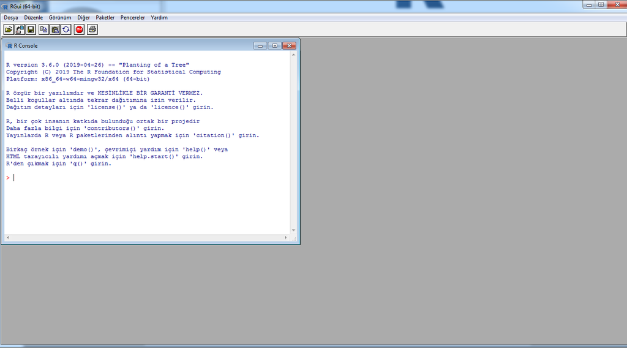

## RStudio

- The R Console by itself is not very interesting and useful. A tool named RStudio is designed to use R more efficient and easily.
- RStudio can be installed after installing R.
- RStudio won't work without R. R has to be installed on your computer.
- You can think RStudio as an upgrade of R, on visual and functionality terms. It doesn't add anything that R cannot do.
- RStudio can be downloaded from [the website of RStudio](https://rstudio.com/products/rstudio/)

## Using R and RStudio from Posit Cloud

- If you are a beginner at R and will only use it for the lecture then you may not want to install it into your computer.
- A great alternative for this is to use **Posit Cloud**.
- Posit is the company that is the founder of RStudio and provides a cloud solution for using R and Rstudio.
- First, go to [the website of Posit](https://posit.cloud)
- Click *Sign Up* at the upper right part of the page

[figure not shown]

- Then, select the free plan and click *Learn more*.
- The *Free Plan* gives you 25 hours of computing time per month which should be sufficient for this course.
- If you ever think that you are going to exceed the limit you can always download and install R and RStudio to your computer for free.

[figure not shown]

- Click *Sign Up* at the next page.

[figure not shown]

- Enter your *e-mail*, *a password*, *your name* and *your surname* to register to posit cloud.

[figure not shown]

- After registering and possibly confirming your mail address, you can login with your e-mail and password.
- You will encounter the following page when you successfully login to the Posit Cloud.
- Select *New Project* and *New RStudio Project* from the upper right buttons.

[figure not shown]

- After a short period of deployment time, a fresh Rstudio will open as in the following picture.

[figure not shown]

- Give a new name to your project and open a R script to work on from the menu *File $\rightarrow$ New File $\rightarrow$ R Script*.

[figure not shown]

- Now you can start to use RStudio in cloud and make your computations.

[figure not shown]

## Advantages of R

- **Open Source:**
  - There is no clear difference between user and developer.
  - A unique solution for the given problem can be constructed.
  - You are not limited to pre-defined options by a fixed user interface as is common in proprietary software.
  - Open source also allows to use the program freely without spending any money.
- **Flexibility:**
  - Gives access to the source code, allows to modify and improve it according to the needs.
  - Ability to further developments and capacity increase with tools like RStudio and Shiny.
  - New packages to solve a certain problem is consistently added to the R repository.
  - Ability to produce reports in PDF and HTML format.
- **Community:**
  - R has a lot of material in online platforms, in books and in courses.
  - A lot of information can be found via Q&A websites, social media networks, and numerous blogs.

## Some useful websites to get help

Typically, a problem you may be encountering is not new and others have faced, solved, and documented the same issue online.

- The following resources can be used to search for online help. Although, I typically just google the problem and find answers relatively quickly.
- **RSiteSearch("key phrase"):** searches for the key phrase in help manuals and archived mailing lists on the R Project website at http://search.r-project.org/.
- **Stack Overflow:** a searchable Q&A site oriented toward programming issues. 75 % of my answers typically come from Stack Overflow questions tagged for R at http://stackoverflow.com/questions/tagged/r.
- **Cross Validated:** a searchable Q&A site oriented toward statistical analysis. Many questions regarding specific statistical functions in R are tagged for R at http://stats.stackexchange.com/questions/tagged/r.
- **R--seek:** a Google custom search that is focused on R-specific websites. Located at http://rseek.org/
- **R -bloggers:** a central hub of content collected from over 500 bloggers who provide news and tutorials about R. Located at http://www.r-bloggers.com/
- **ChatGPT** obviously.

# Basic Calculations and Defining Objects in R

- You can either write a code directly into the console or you can use a script.
- Using a script is more efficient. Because it is easier to write modify and save a R Code in a script.
- Open a script with *File $\rightarrow$ New File $\rightarrow$ R Script* or you can use shortcut *Ctrl + Shift + N*

## Objects

- R works by creating **objects** and using various functions calls that **create** and **use** these objects. For example;
  - Vectors of numbers, logical values (TRUE and FALSE), character strings and even complex numbers.
  - Matrices and general n-way arrays
  - Lists - arbitrary collections of objects of any type; e.g. list of vectors, list of matrices, etc.
  - Data frames - a general data set type
  - functions (yes even functions are objects)

## Defining Variables in R

- R is case sensitive !!!

```r
x = 5
y <- 8
z <- x+y
z
```

13

## Basic Math in R

```r
43 + 35 # addition
```

78

```r
43 - 35 # subtraction
```

8

```r
12 * 8 # multiplication
```

96

```r
100 / 8 # division
```

12.5

```r
2^4 # power
```

16

```r
100 %% 8 # remainder
```

4

```r
100 %/% 8 # divident
```

12

## Logical Comparisons in R

```r
5 < 8
```

TRUE

```r
2 + 2 == 5
```

FALSE

```r
T == TRUE
```

TRUE

```r
3 * 3 == 9
```

TRUE

```r
3 * 3 != 8
```

TRUE

```r
3 * 3 != 9
```

FALSE

## Functions

- Functions are special commands that are designed for a particular purpose.
- For example `sum()` gives the sum of a numerical values, `sqrt()` takes root of a number etc..
- Functions are always followed by a `()`. Inside the `()` most of the functions take some special values called **arguments**.
- Lets look at the `help` page for the `sqrt()` function.

```
?sqrt
```

[output not shown]

- `sqrt()` function only takes one argument `x` which is either a single number, or arrays of numbers.

```r
sqrt(8)
```

2.82842712474619

```r
sqrt(c(1,4,9,16,25))
```

1. 1

2. 2

3. 3

4. 4

5. 5

- Lets look at the `help` page for the `sum()` function.

```
?sum
```

[output not shown]

- According to the help file the usage of function is `sum(..., na.rm = FALSE)`
- `sum()` function takes two arguments.
  - `...` numeric or complex or logical vectors.
  - `na.rm` logical. Should missing values (including NaN) be removed?
- The second argument `na.rm` has a default value of `FALSE`. A default value means that if you don't specify a value, it will take the default value, here `FALSE`.

```r
x<- c(6, 8, 10, 12, 14)
```

```r
sum(x)
```

50

```r
sum(x, na.rm = FALSE)
```

50

```r
sum(x, na.rm = TRUE)
```

50

```r
y<- c(6, 8, 10, 12, NA)
```

```r
sum(y)
```

<NA>

```r
sum(y, na.rm = FALSE)
```

<NA>

```r
sum(y, na.rm = TRUE)
```

36

```r
z <- c(T, T, F, F, F, T, T)
sum(z)
```

4

## Packages

- Some functions are not contained locally in R. They are called packages and they should be installed when needed.
- R contains one or more libraries of packages. A package contain various functions and data sets for numerous purposes, e.g. `e1071` package, `spatstat` package and `DandEFA` package, etc.
- Some packages are a part of the R. Others should be downloaded from the Comphrensive R Archive Network.
- To access all of the functions and data sets of a particular package; for example, DandEFA; it must be loaded to the workspace:

```r
# install.packages('DandEFA')
```

```r
library(DandEFA) # Buy you have to call and load a package every new R session.
```

- You can also use Rstudio to download multiple packages easily and at once.
- `Tools -> Install Packages`

[figure not shown]

## An Example for Packages: DandEFA Package

- Using packages to utilize various methods and algorithms.
- **DandEFA** package contains functions for a particular analysis called **factor analysis**.
- Factor Analysis is a method for categorize variables into groups to find the relationship between the variables in the same group.
- The package contains functions:
  - **factload**: A method for producing the factor loadings
  - **dandelion**: A method for visualizing the factor loadings

```
help(package="DandEFA")
```

[figure not shown]

- Alternatively you can also use the bottom-right panel in RStudio to get info on a specific function:

[figure not shown]

```r
#packageDescription("DandEFA")
```

- You don't have to understand the following code, but understand that the following code is taken from the documentation from the `DandEFA` package and can be applied directly.

```
Loadings:
     [,1]   [,2]   [,3]   [,4]   [,5]
X10A                0.103 -0.101 -0.224
X10B
X10C         0.106               -0.129
X11A                      -0.544 -0.130
X11B                      -0.514
X11C -0.129 -0.105        -0.500
X11D                      -0.475
X12A -0.116        -0.152 -0.338  0.318
X12B        -0.254 -0.133 -0.328  0.256
X12C        -0.149 -0.136 -0.298  0.249
X13A         0.549
X13B         0.504
X13C         0.583
X13D         0.398
X13E         0.595
X13F         0.458
X17A -0.539        -0.419 -0.140
X17B  0.633         0.156        -0.164
X17C -0.350        -0.450 -0.185
X17D  0.727         0.222        -0.173
X17E -0.325        -0.337 -0.164
X17F -0.611        -0.445 -0.143
X17G -0.252        -0.481 -0.145  0.157
X18A -0.303        -0.420 -0.267 -0.138
X18B  0.537  0.146         0.152 -0.152
X18C -0.353        -0.326 -0.192
X18D -0.416        -0.413 -0.277
X18E -0.160        -0.381 -0.239 -0.125
X19A -0.540        -0.443 -0.135 -0.254
X19B  0.633  0.119
X19C  0.694         0.158
X19D -0.519        -0.424 -0.163 -0.256
X19E  0.687  0.112
X19F -0.415        -0.462 -0.124 -0.361
X19G -0.313        -0.491 -0.220 -0.359
X19H -0.383        -0.500 -0.214 -0.361
X19I  0.690
X19J -0.238        -0.507 -0.158
X19K               -0.620         0.142
X19L               -0.714         0.124
X19M               -0.749         0.101
X19N -0.184        -0.654
X21A               -0.120 -0.106

                [,1]  [,2]  [,3]  [,4]  [,5]
SS loadings    5.576 1.851 4.965 1.987 1.076
Proportion Var 0.130 0.043 0.115 0.046 0.025
Cumulative Var 0.130 0.173 0.288 0.334 0.359
```

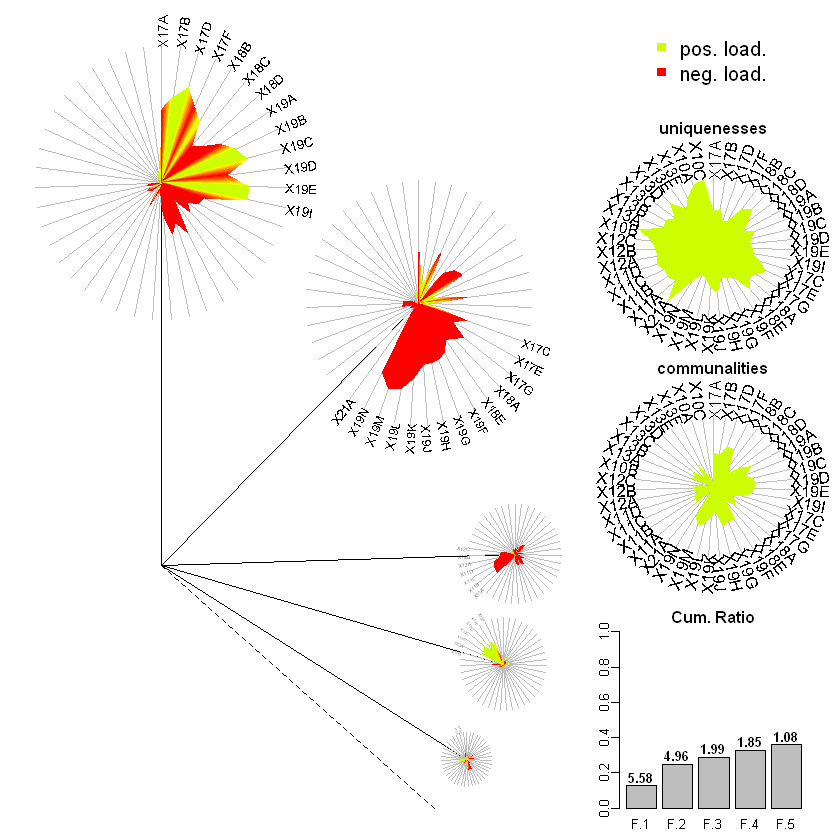

```r
library(DandEFA) # loading the package

data(timss2011) # loading the dataset

timss2011 <- na.omit(timss2011) # removing the rows with missing values

dandpal <- rev(rainbow(100, start = 0, end = 0.2)) # Choose colors for visualisation

facl <- factload(timss2011,nfac=5,method="prax",cormeth="spearman") # Find the factor loadings
facl # Show the factor loadings

dandelion(facl,bound=0,mcex=c(1,1.2),palet=dandpal) # Visualise
```

- In summary, packages provide a flexible environment.
- Employing multiple methods and algorithms in the same time
- Programming and using packages are two core elements in R.

## Working Directory

- In order to work in R, you should specify a active working directory. In brief this is the location where R will get and save the files.
- You can call the active working directory with the command `getwd()`
- **Note**: If you don't understand the concept of `working directory`, you will probably get errors during importing dataset and locating files. So be careful.

```r
# returns path for the current working directory
getwd()
```

'C:/Users/erhan/Documents/FEF1002'

- You can change your active working directory either by using `setwd()` function or by using *Session $\rightarrow$ Set Working Directory $\rightarrow$ To Source File Location* after saving a script.

```r
# set the working directory to a specified directory
setwd("C:/Users/erhan/Desktop")
getwd()
```

'C:/Users/erhan/Desktop'

```r
setwd("C:/Users/erhan/Documents/FEF1002")
getwd()
```

'C:/Users/erhan/Documents/FEF1002'

# Data Types in R Programming {#data-types}

## Vectors

- Vectors are one dimensional arrays that keeps only one type of variables.
- All the elements in a vector should be the same type. (Numeric, string, logical etc.)

```r
x <- c(10.4, 5.6, 3.1, 6.4, 21.7) # Numeric Vector
x
```

1. 10.4

2. 5.6

3. 3.1

4. 6.4

5. 21.7

```r
x <- c("boy","girl","boy","girl","boy","boy") # character vector
x
```

1. 'boy'

2. 'girl'

3. 'boy'

4. 'girl'

5. 'boy'

6. 'boy'

```r
x <- c(TRUE,TRUE,FALSE,TRUE,TRUE,FALSE) # logical vector
x
```

1. TRUE

2. TRUE

3. FALSE

4. TRUE

5. TRUE

6. FALSE

```r
# or you can use
x <- c(T,T,F,T,T,F) # logical vector
x
```

1. TRUE

2. TRUE

3. FALSE

4. TRUE

5. TRUE

6. FALSE

- What if I put different kind of values in a vector.

```r
c(10, 20, 26, T) # numeric and logical values
```

1. 10

2. 20

3. 26

4. 1

```r
c(10, 20, 26, "apple") # numeric and string
```

1. '10'

2. '20'

3. '26'

4. 'apple'

```r
c(T, F, "apple", "banana") # logical and string
```

1. 'TRUE'

2. 'FALSE'

3. 'apple'

4. 'banana'

```r
c(T, "apple", 10) # logical, string, numeric
```

1. 'TRUE'

2. 'apple'

3. '10'

- Accessing elements in a vector is easy,

```r
x <- c(10.4, 5.6, 3.1, 6.4, 21.7) # Numeric Vector
```

- Indexing in R starts with `1` opposing to some programming languages like Python which starts indexing with `0`.
- Select fifth element of the vector.

```r
x[5]
```

21.7

- Select first, third and fifth element of the vector.

```r
ind <- c(1,3,5)
x[ind]
```

1. 10.4

2. 3.1

3. 21.7

- Select second and fourth element of the vector.

```r
ind <- c(F,T,F,T,F)
x[ind]
```

1. 5.6

2. 6.4

- A logical operation over a vector would create a logical vector (important!!)

```r
x <- c(10.4, 5.6, 3.1, 6.4, 21.7) # Numeric Vector
```

- Find whether an element is higher than 7.

```r
ind <- (x > 7)
ind
```

1. TRUE

2. FALSE

3. FALSE

4. FALSE

5. TRUE

- Find elements that is higher than 7.

```r
x[ind]
```

1. 10.4

2. 21.7

- Find elements that is equal or lower than 7.

```r
x[!ind]
```

1. 5.6

2. 3.1

3. 6.4

- We will use indices to manipulate data sets later. But a shorter version of the code is

```r
x <- c(10.4, 5.6, 3.1, 6.4, 21.7) # Numeric Vector
```

```r
x[x > 7]
```

1. 10.4

2. 21.7

- A logical operator checks whether the both sides have equal length or one side has length 1.

```r
x <- c(10.4, 5.6, 3.1, 6.4, 21.7)
y <- c(4, 7, 8, 2, 35)
```

```r
ind <- (x > y)
ind
```

1. TRUE

2. FALSE

3. FALSE

4. TRUE

5. FALSE

- If the number of elements are not equal:

```r
x <- c(10.4, 5.6, 3.1, 6.4, 21.7)
y <- c(4,7,8,2)
```

- will give an output but with a warning.

```r
ind <- (x > y)
```

```
Warning message in x > y:
"longer object length is not a multiple of shorter object length"
```

```r
ind
```

1. TRUE

2. FALSE

3. FALSE

4. TRUE

5. TRUE

### Modifying Vectors

- Any element of the vector can be modified easily:

```r
x <- c(10.4, 5.6, 3.1, 6.4, 21.7)
```

```r
x[4] <- 7.3
x
```

1. 10.4

2. 5.6

3. 3.1

4. 7.3

5. 21.7

- A group of elements can be modified too

```r
x <- c(10.4, 5.6, 3.1, 6.4, 21.7)
```

```r
x[x > 7] <- 100
x
```

1. 100

2. 5.6

3. 3.1

4. 6.4

5. 100

- Some advance stuff: (data imputation)

```r
x <- c(10.4, NA, 3.1, 6.4, NA)
```

```r
is.na(x)
```

1. FALSE

2. TRUE

3. FALSE

4. FALSE

5. TRUE

```r
x[is.na(x)] <- mean(x, na.rm = TRUE)
x
```

1. 10.4

2. 6.63333333333333

3. 3.1

4. 6.4

5. 6.63333333333333

### Manipulating vectors

- Merging vectors with c():

```r
x <- c(10.4, 5.6, 3.1, 6.4, 21.7)
y <- c(4, 7, 8, 2, 35)
z <- c(x,y)
```

```r
z
```

1. 10.4

2. 5.6

3. 3.1

4. 6.4

5. 21.7

6. 4

7. 7

8. 8

9. 2

10. 35

- Summation or multiplication over vectors. **Note**: Again both vectors either have be of same size or one has to be of length one.

```r
x
y
```

1. 10.4

2. 5.6

3. 3.1

4. 6.4

5. 21.7

1. 4

2. 7

3. 8

4. 2

5. 35

```r
z <- x + y
z
```

1. 14.4

2. 12.6

3. 11.1

4. 8.4

5. 56.7

```r
z <- x * y
z
```

1. 41.6

2. 39.2

3. 24.8

4. 12.8

5. 759.5

### Generating Sequences

- the colon `:`,

```r
x <- 1:10
x
```

1. 1

2. 2

3. 3

4. 4

5. 5

6. 6

7. 7

8. 8

9. 9

10. 10

```r
x <- 2*(1:10)
x
```

1. 2

2. 4

3. 6

4. 8

5. 10

6. 12

7. 14

8. 16

9. 18

10. 20

- the `seq()` function.

```r
x <- seq(1,10)
x
```

1. 1

2. 2

3. 3

4. 4

5. 5

6. 6

7. 7

8. 8

9. 9

10. 10

```r
x <- seq(1,10,by=0.5)
x
```

1. 1

2. 1.5

3. 2

4. 2.5

5. 3

6. 3.5

7. 4

8. 4.5

9. 5

10. 5.5

11. 6

12. 6.5

13. 7

14. 7.5

15. 8

16. 8.5

17. 9

18. 9.5

19. 10

- the `rep()` function.

```r
x <- rep(3, 10)
x
```

1. 3

2. 3

3. 3

4. 3

5. 3

6. 3

7. 3

8. 3

9. 3

10. 3

```r
y <- rep(c(F,T,F,T,T,T),3)
y
```

1. FALSE

2. TRUE

3. FALSE

4. TRUE

5. TRUE

6. TRUE

7. FALSE

8. TRUE

9. FALSE

10. TRUE

11. TRUE

12. TRUE

13. FALSE

14. TRUE

15. FALSE

16. TRUE

17. TRUE

18. TRUE

```r
z1 <- rep(c(4,7,8,2,35),each=3)
z1
```

1. 4

2. 4

3. 4

4. 7

5. 7

6. 7

7. 8

8. 8

9. 8

10. 2

11. 2

12. 2

13. 35

14. 35

15. 35

```r
z2 <- rep(c(4,7,8,2,35), times = 3)
z2
```

1. 4

2. 7

3. 8

4. 2

5. 35

6. 4

7. 7

8. 8

9. 2

10. 35

11. 4

12. 7

13. 8

14. 2

15. 35

### An Example on Vectors

```r
x <- c(2,4,6,8,10)
y <- c("apple", "banana", "peach", "walnut", "apple")
```

```r
sum(x)
```

30

```r
sum(x < 6)
```

2

```r
mean(x < 6)
```

0.4

```r
x[x < 6]
```

1. 2

2. 4

```r
x
y
```

1. 2

2. 4

3. 6

4. 8

5. 10

1. 'apple'

2. 'banana'

3. 'peach'

4. 'walnut'

5. 'apple'

```r
mean(y=="apple")
```

0.4

```r
mean(x > 6 & y=="apple")
```

0.2

## Factors

A factor is a special type of vector used to represent categorical data, e.g. gender, social class, etc.

- Stored internally as a numeric vector with values $1, 2, ..., k$, where $k$ is the number of levels.
- Can have either ordered and unordered factors.
- A factor with $k$ levels is stored internally consisting of 2 items.
  - a vector of $k$ integers
  - a character vector containing strings describing what the $k$ levels are.

### Factor Example

- We have a numeric vector containing the satisfaction levels.

```r
satisfaction <- c(1, 3, 4, 2, 2, 3, 4, 2, 1, 2, 1, 1, 4, 3)
```

- Want to treat this as a categorical variable and so the second line creates a factor. The `levels=1:5` argument indicates that there are 5 levels of the factor. We also set the labels for each factor.

```r
fsatisfaction <- factor(satisfaction,
                        levels=1:5,
                        labels = c("very poor", "poor", "average","good", "very good"))
```

```r
fsatisfaction
```

1. very poor

2. average

3. good

4. poor

5. poor

6. average

7. good

8. poor

9. very poor

10. poor

11. very poor

12. very poor

13. good

14. average

**Levels**:**

1. 'very poor'

2. 'poor'

3. 'average'

4. 'good'

5. 'very good'

## Matrices

- Matrices are used for many purposes in R.
- First let's create a vector from a normal distribution that we will convert to matrix.

```r
set.seed(100) # to ensure the numbers are same for each of you
m <- rnorm(12,0,1)
m
```

1. -0.502192350531457

2. 0.131531165327303

3. -0.07891708981887

4. 0.886784809417845

5. 0.116971270510841

6. 0.318630087617032

7. -0.58179068471591

8. 0.714532710891568

9. -0.825259425862769

10. -0.359862131395465

11. 0.0898861437775305

12. 0.0962744602851301

```r
dim(m) <- c(3,4)
m
```

| -0.50219235 | 0.8867848 | -0.5817907 | -0.35986213 |
| --- | --- | --- | --- |
| 0.13153117 | 0.1169713 | 0.7145327 | 0.08988614 |
| -0.07891709 | 0.3186301 | -0.8252594 | 0.09627446 |

- or you can specify the dimensions with the `matrix()` function

```r
set.seed(100) # to ensure the numbers are same for each of you
m <- rnorm(12)
m
```

1. -0.502192350531457

2. 0.131531165327303

3. -0.07891708981887

4. 0.886784809417845

5. 0.116971270510841

6. 0.318630087617032

7. -0.58179068471591

8. 0.714532710891568

9. -0.825259425862769

10. -0.359862131395465

11. 0.0898861437775305

12. 0.0962744602851301

```r
m  <- matrix(m, nrow = 3, ncol = 4, byrow = F)
m
```

| -0.50219235 | 0.8867848 | -0.5817907 | -0.35986213 |
| --- | --- | --- | --- |
| 0.13153117 | 0.1169713 | 0.7145327 | 0.08988614 |
| -0.07891709 | 0.3186301 | -0.8252594 | 0.09627446 |

- Basic functions on matrices.
  - `nrow()` and `ncol()` calls numbers of rows and columns.
  - `t()` calls the transpose of the matrix.
  - `rownames()` and `colnames()` are the names of columns and rows.

```r
set.seed(100) # to ensure the numbers are same for each of you
m <- rnorm(12)
m  <- matrix(m, nrow = 3, ncol = 4, byrow = F)
m
```

| -0.50219235 | 0.8867848 | -0.5817907 | -0.35986213 |
| --- | --- | --- | --- |
| 0.13153117 | 0.1169713 | 0.7145327 | 0.08988614 |
| -0.07891709 | 0.3186301 | -0.8252594 | 0.09627446 |

```r
nrow(m)
```

3

```r
ncol(m)
```

4

```r
colnames(m) <- c("A", "B", "C", "D")
m
```

| A | B | C | D |
| --- | --- | --- | --- |
| -0.50219235 | 0.8867848 | -0.5817907 | -0.35986213 |
| 0.13153117 | 0.1169713 | 0.7145327 | 0.08988614 |
| -0.07891709 | 0.3186301 | -0.8252594 | 0.09627446 |

### Merging Vectors

- `rbind()` and `cbind()` functions merges vectors or matrices into matrices.

```r
set.seed(100)
X1 <- rnorm(12)
X2 <- 1:12
```

```r
m <- cbind(X1,X2)
m
```

| X1 | X2 |
| --- | --- |
| -0.50219235 | 1 |
| 0.13153117 | 2 |
| -0.07891709 | 3 |
| 0.88678481 | 4 |
| 0.11697127 | 5 |
| 0.31863009 | 6 |
| -0.58179068 | 7 |
| 0.71453271 | 8 |
| -0.82525943 | 9 |
| -0.35986213 | 10 |
| 0.08988614 | 11 |
| 0.09627446 | 12 |

- Number of columns should be equal for `rbind`.
- Likewise, number of rows should be equal for `cbind`.
- Create two matrices

```r
set.seed(100)
data_1 <- matrix(rnorm(12),nrow=3,ncol=4,byrow=T)
data_2 <- matrix(rnorm(16),nrow=4,ncol=4,byrow=F)
```

- and combine them.

```r
data_new <- rbind(data_1,data_2)
data_new
```

| -0.50219235 | 0.1315312 | -0.07891709 | 0.88678481 |
| --- | --- | --- | --- |
| 0.11697127 | 0.3186301 | -0.58179068 | 0.71453271 |
| -0.82525943 | -0.3598621 | 0.08988614 | 0.09627446 |
| -0.20163395 | -0.3888542 | -0.43808998 | -0.81437912 |
| 0.73984050 | 0.5108563 | 0.76406062 | -0.43845057 |
| 0.12337950 | -0.9138142 | 0.26196129 | -0.72022155 |
| -0.02931671 | 2.3102968 | 0.77340460 | 0.23094453 |

### Indexing Matrices

```r
set.seed(100) # to ensure the numbers are same for each of you
m  <- matrix(rnorm(12), nrow = 3, ncol = 4, byrow = F)
m
```

| -0.50219235 | 0.8867848 | -0.5817907 | -0.35986213 |
| --- | --- | --- | --- |
| 0.13153117 | 0.1169713 | 0.7145327 | 0.08988614 |
| -0.07891709 | 0.3186301 | -0.8252594 | 0.09627446 |

- Extract the first row.

```r
m[1,]
```

1. -0.502192350531457

2. 0.886784809417845

3. -0.58179068471591

4. -0.359862131395465

- Extract the second column.

```r
m[,2]
```

1. 0.886784809417845

2. 0.116971270510841

3. 0.318630087617032

- Extract all the rows except the first row.

```r
m[-1,]
```

| 0.13153117 | 0.1169713 | 0.7145327 | 0.08988614 |
| --- | --- | --- | --- |
| -0.07891709 | 0.3186301 | -0.8252594 | 0.09627446 |

- Extract all the columns except the first and the third one.

```r
m[, -c(1,3)]
```

| 0.8867848 | -0.35986213 |
| --- | --- |
| 0.1169713 | 0.08988614 |
| 0.3186301 | 0.09627446 |

```r
index_row <- 1:3
index_col <- c(1,3,4)
```

- Extract the first, second and third row and first, third and fourth column.

```r
m[index_row,index_col]
```

| -0.50219235 | -0.5817907 | -0.35986213 |
| --- | --- | --- |
| 0.13153117 | 0.7145327 | 0.08988614 |
| -0.07891709 | -0.8252594 | 0.09627446 |

- or alternatively you can use

```r
m[1:3, c(1,3,4)]
```

| -0.50219235 | -0.5817907 | -0.35986213 |
| --- | --- | --- |
| 0.13153117 | 0.7145327 | 0.08988614 |
| -0.07891709 | -0.8252594 | 0.09627446 |

## Data Frames

- A data frame
  - can be thought of as a data matrix or data set;
  - is a list of vectors and/or factors of the same length;
  - has a unique set of row names.
- Data in the same position across columns come from the same experimental unit.
- Can create data frames from pre-existing variables.
- The main spec of data frame is the ability to keep variables with different forms.
- Both numeric, string and logical variables can be reserved in a single dataframe unlike vectors and matrices.
- Creata a vector called `mean_weight`.

```r
mean_weight <- c(179.3, 179.9, 180.5, 180.1, 180.3, 180.4)
mean_weight
```

1. 179.3

2. 179.9

3. 180.5

4. 180.1

5. 180.3

6. 180.4

- Creata a vector called `Gender`.

```r
Gender <- c("M", "M", "F", "F", "M", "M")
Gender
```

1. 'M'

2. 'M'

3. 'F'

4. 'F'

5. 'M'

6. 'M'

- Convert `Gender` to a factor variable.

```r
Gender <- factor(Gender,levels=c("M","F"))
Gender
```

1. M

2. M

3. F

4. F

5. M

6. M

**Levels**:**

1. 'M'

2. 'F'

- Combine both vectors into a dataframe.

```r
d <- data.frame(mean_weight, Gender)
d
```

| mean_weight | Gender |
| --- | --- |
| 179.3 | M |
| 179.9 | M |
| 180.5 | F |
| 180.1 | F |
| 180.3 | M |
| 180.4 | M |

- Note that the resulting variables have different data types.
  - `mean_weight` is numeric.
  - `Gender` is factor.
- This wouldn't be the case if we try to store them in a matrix as they can only store one type of variable.

### Converting other Structures to Dataframes

You can also convert other data types to dataframes

- Converting a matrix to a data frame:

```r
d <- cbind(mean_weight,Gender)
d
```

| mean_weight | Gender |
| --- | --- |
| 179.3 | 1 |
| 179.9 | 1 |
| 180.5 | 2 |
| 180.1 | 2 |
| 180.3 | 1 |
| 180.4 | 1 |

- We created a matrix from `mean_weight` and `Gender`. `Gender` is automatically converted to a numerical variable as variables in the matrices should be in the same data type.

```r
d <- as.data.frame(d)
d
```

| mean_weight | Gender |
| --- | --- |
| 179.3 | 1 |
| 179.9 | 1 |
| 180.5 | 2 |
| 180.1 | 2 |
| 180.3 | 1 |
| 180.4 | 1 |

- Even if we convert the matrix to a dataframe the categorical names of the `Gender` is gone.

### Accesssing elements in a dataframe

- There are a lot of different way to access rows and columns in a dataframe.
- You can either use single bracket `[ ]`, double bracket `[[ ]]` or `$` sign.
- Investigate the following code snippets to understand how `R` behaves.

```r
d$mean_weight # output in vector format
```

1. 179.3

2. 179.9

3. 180.5

4. 180.1

5. 180.3

6. 180.4

```r
d[["mean_weight"]] # output in vector format
```

1. 179.3

2. 179.9

3. 180.5

4. 180.1

5. 180.3

6. 180.4

```r
d[,1] # output in vector format
```

1. 179.3

2. 179.9

3. 180.5

4. 180.1

5. 180.3

6. 180.4

```r
d[,"mean_weight"] # output in vector format
```

1. 179.3

2. 179.9

3. 180.5

4. 180.1

5. 180.3

6. 180.4

```r
d["mean_weight"] # output in dataframe format
```

| mean_weight |
| --- |
| 179.3 |
| 179.9 |
| 180.5 |
| 180.1 |
| 180.3 |
| 180.4 |

```r
d[1] # output in dataframe format
```

| mean_weight |
| --- |
| 179.3 |
| 179.9 |
| 180.5 |
| 180.1 |
| 180.3 |
| 180.4 |

- You can access a subset of rows by indexing the data frame

```r
d[c(1,4,5),] # Shows 1., 4. and 5. rows of the dataframe
```

|  | mean_weight | Gender |
| --- | --- | --- |
| 1 | 179.3 | 1 |
| 4 | 180.1 | 2 |
| 5 | 180.3 | 1 |

- It is suggested that you use `drop=FALSE` when indexing (to sustain the data frame type).

```r
d[1:3,"mean_weight"]
```

1. 179.3

2. 179.9

3. 180.5

```r
d[1:3,"mean_weight",drop=FALSE]
```

| mean_weight |
| --- |
| 179.3 |
| 179.9 |
| 180.5 |

### Creating a new variable in a dataframe

```r
d
```

| mean_weight | Gender |
| --- | --- |
| 179.3 | 1 |
| 179.9 | 1 |
| 180.5 | 2 |
| 180.1 | 2 |
| 180.3 | 1 |
| 180.4 | 1 |

```r
d$color <- NA
d
```

| mean_weight | Gender | color |
| --- | --- | --- |
| 179.3 | 1 | NA |
| 179.9 | 1 | NA |
| 180.5 | 2 | NA |
| 180.1 | 2 | NA |
| 180.3 | 1 | NA |
| 180.4 | 1 | NA |

```r
d$weight_two_times <- d$mean_weight*2
d
```

| mean_weight | Gender | color | weight_two_times |
| --- | --- | --- | --- |
| 179.3 | 1 | NA | 358.6 |
| 179.9 | 1 | NA | 359.8 |
| 180.5 | 2 | NA | 361.0 |
| 180.1 | 2 | NA | 360.2 |
| 180.3 | 1 | NA | 360.6 |
| 180.4 | 1 | NA | 360.8 |

# Importing Data

- The most popular functions for reading data sets
  - `read.table()` function is used mainly for reading data from formatted text files.
  - `read.csv()` function is used mainly for reading data from files with csv format ("Comma Separated Values"format)
  - `read_excel()` function is used to read data directly from an excel file. It requires the external package `readxl`.

## Datasets

You can download the datasets used in this lecture from the lecturers AVESIS page.

## Pima Data Set

- Indian females of Pima heritage (Native americans living in an area consisting of what is now central and southern Arizona)
- Columns (or Variables) of the Pima data set:
  - **NTP**: number of times pregnant
  - **PGC**: Plasma glucose concentration a 2 hours in an oral glucose tolerance test
  - **DBP**: Diastolic blood pressure (mm Hg)
  - **TSFT**: Triceps skin fold thickness (mm)
  - **SI**: 2-Hour serum insulin (mu U/ml)
  - **BMI**: Body mass index (weight in kg/(height in meter square))
  - **Diabetes pedigree function**:
  - **Age**: Age (years)
  - **Diabetes**: f0,1g value 1 is interpreted as "tested positive for diabetes"
- First, you have to check whether the working directory of R and the location of file matches.

```r
getwd()
```

'C:/Users/erhan/Documents/FEF1002'

- The location of the working directory can be changed with `setwd()` function.
- Alternatively you can change the working directory to the where the Rcode is located with RStudio by using:

`Session` -> `Set Working Directory` -> `To Source File Location`

## Working on the Posit Cloud

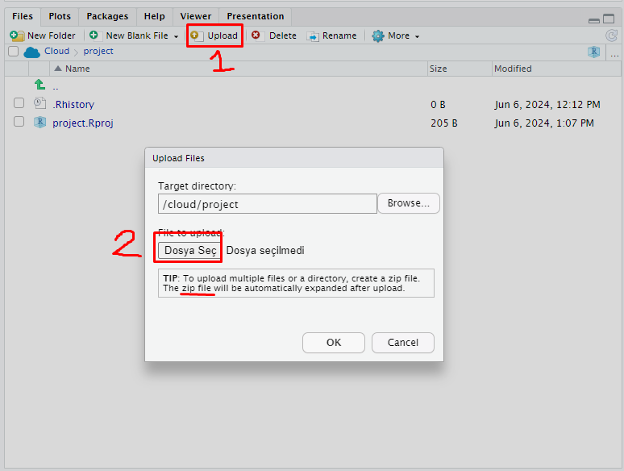

- From the file upload menu select the data files you wish to upload. If you intend to upload multiple files create a *zip file* from the datasets.

[figure not shown]

- Posit Cloud will automatically extract it once it uploads the zip file to the cloud.
- For example, *week1_dataset.zip* contains five different data formats for the **pima** dataset. When it is uploaded all five data files will be extracted under the folder *week1_dataset*.

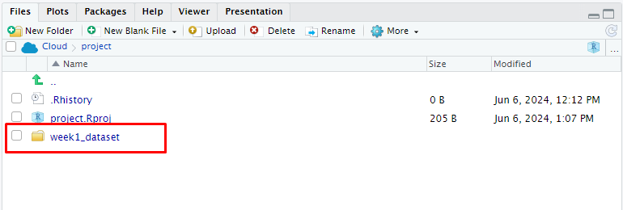

- Now you can use the following importing functions inside the Posit Cloud to call dataset into R.

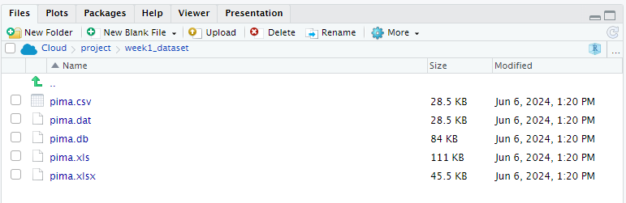

## Importing Data from Text Files

- Now let's check our working directory once more.

```r
getwd()
```

'C:/Users/erhan/Documents/FEF1002'

- Now if I want to import any data by using a function with R, I have to either:
  - Provide the full location of the dataset inside the function such as: `C:/Users/erhan/Documents/FEF1002/pima.dat`
  - or since my working directory is the folder `FEF1002`, if I put my `pima.dat` data inside the `FEF1002` folder, it would be sufficient for me to provide `pima.dat` as the location.
- So in practice both

```r
pima_data <- read.table("pima.dat", header = TRUE, sep = " ")
```

```r
head(pima_data)
```

| NTP | PGC | DBP | TSFT | SI | BMI | DPF | Age | Diabetes |
| --- | --- | --- | --- | --- | --- | --- | --- | --- |
| 6 | 148 | 72 | 35 | 0 | 33.6 | 0.627 | 50 | positive |
| 1 | 85 | 66 | 29 | 0 | 26.6 | 0.351 | 31 | negative |
| 8 | 183 | 64 | 0 | 0 | 23.3 | 0.672 | 32 | positive |
| 1 | 89 | 66 | 23 | 94 | 28.1 | 0.167 | 21 | negative |
| 0 | 137 | 40 | 35 | 168 | 43.1 | 2.288 | 33 | positive |
| 5 | 116 | 74 | 0 | 0 | 25.6 | 0.201 | 30 | negative |

```r
pima_data <- read.table("C:/Users/erhan/Documents/FEF1002/pima.dat",
                        header = TRUE, sep = " ")
```

will work and import the data.

- Remember to change `C:/Users/erhan/Documents/FEF1002/pima.dat` to where the `pima.dat` is actually located.
- You can use both approach for the following data importing processes.

```r
head(pima_data)
```

| NTP | PGC | DBP | TSFT | SI | BMI | DPF | Age | Diabetes |
| --- | --- | --- | --- | --- | --- | --- | --- | --- |
| 6 | 148 | 72 | 35 | 0 | 33.6 | 0.627 | 50 | positive |
| 1 | 85 | 66 | 29 | 0 | 26.6 | 0.351 | 31 | negative |
| 8 | 183 | 64 | 0 | 0 | 23.3 | 0.672 | 32 | positive |
| 1 | 89 | 66 | 23 | 94 | 28.1 | 0.167 | 21 | negative |
| 0 | 137 | 40 | 35 | 168 | 43.1 | 2.288 | 33 | positive |
| 5 | 116 | 74 | 0 | 0 | 25.6 | 0.201 | 30 | negative |

```r
str(pima_data)
```

```
'data.frame':	768 obs. of  9 variables:
 $ NTP     : int  6 1 8 1 0 5 3 10 2 8 ...
 $ PGC     : int  148 85 183 89 137 116 78 115 197 125 ...
 $ DBP     : int  72 66 64 66 40 74 50 0 70 96 ...
 $ TSFT    : int  35 29 0 23 35 0 32 0 45 0 ...
 $ SI      : int  0 0 0 94 168 0 88 0 543 0 ...
 $ BMI     : num  33.6 26.6 23.3 28.1 43.1 25.6 31 35.3 30.5 0 ...
 $ DPF     : num  0.627 0.351 0.672 0.167 2.288 ...
 $ Age     : int  50 31 32 21 33 30 26 29 53 54 ...
 $ Diabetes: Factor w/ 2 levels "negative","positive": 2 1 2 1 2 1 2 1 2 2 ...
```

- Here, the argument `header = TRUE` is used to denote that the variable names are given at the first line of the data.
- The argument `sep = " "` is used to denote how the variables are separated from each other. For this dataset `space` is used to separate variables.

## Importing Data From CSV Files

```r
pima_csv <- read.csv("pima.csv", header = TRUE, sep = ",")
```

```r
head(pima_csv)
```

| NTP | PGC | DBP | TSFT | SI | BMI | DPF | Age | Diabetes |
| --- | --- | --- | --- | --- | --- | --- | --- | --- |
| 6 | 148 | 72 | 35 | 0 | 33.6 | 0.627 | 50 | positive |
| 1 | 85 | 66 | 29 | 0 | 26.6 | 0.351 | 31 | negative |
| 8 | 183 | 64 | 0 | 0 | 23.3 | 0.672 | 32 | positive |
| 1 | 89 | 66 | 23 | 94 | 28.1 | 0.167 | 21 | negative |
| 0 | 137 | 40 | 35 | 168 | 43.1 | 2.288 | 33 | positive |
| 5 | 116 | 74 | 0 | 0 | 25.6 | 0.201 | 30 | negative |

```r
str(pima_csv)
```

```
'data.frame':	768 obs. of  9 variables:
 $ NTP     : int  6 1 8 1 0 5 3 10 2 8 ...
 $ PGC     : int  148 85 183 89 137 116 78 115 197 125 ...
 $ DBP     : int  72 66 64 66 40 74 50 0 70 96 ...
 $ TSFT    : int  35 29 0 23 35 0 32 0 45 0 ...
 $ SI      : int  0 0 0 94 168 0 88 0 543 0 ...
 $ BMI     : num  33.6 26.6 23.3 28.1 43.1 25.6 31 35.3 30.5 0 ...
 $ DPF     : num  0.627 0.351 0.672 0.167 2.288 ...
 $ Age     : int  50 31 32 21 33 30 26 29 53 54 ...
 $ Diabetes: Factor w/ 2 levels "negative","positive": 2 1 2 1 2 1 2 1 2 2 ...
```

- From the code we can understand that column names are included in the data (`header = TRUE`) and variables are separated with `comma` (`sep = ","`)

## Importing Data From Excel Files

- Remember that you can always use an external package to complete a different task
- Suppose we want to import directly from an excel file with `.xls` or `.xlsx` format
- We will use the `readxl` package.

```r
library(readxl) # Remember youj should use install.packages('readxl') if you didn't install it before

pima_xls <- read_excel("pima.xls", sheet = 'pima')
```

```r
head(pima_xls)
```

| NTP | PGC | DBP | TSFT | SI | BMI | DPF | Age | Diabetes |
| --- | --- | --- | --- | --- | --- | --- | --- | --- |
| 6 | 148 | 72 | 35 | 0 | 33.6 | 0.627 | 50 | positive |
| 1 | 85 | 66 | 29 | 0 | 26.6 | 0.351 | 31 | negative |
| 8 | 183 | 64 | 0 | 0 | 23.3 | 0.672 | 32 | positive |
| 1 | 89 | 66 | 23 | 94 | 28.1 | 0.167 | 21 | negative |
| 0 | 137 | 40 | 35 | 168 | 43.1 | 2.288 | 33 | positive |
| 5 | 116 | 74 | 0 | 0 | 25.6 | 0.201 | 30 | negative |

```r
str(pima_xls)
```

```
Classes 'tbl_df', 'tbl' and 'data.frame':	768 obs. of  9 variables:
 $ NTP     : num  6 1 8 1 0 5 3 10 2 8 ...
 $ PGC     : num  148 85 183 89 137 116 78 115 197 125 ...
 $ DBP     : num  72 66 64 66 40 74 50 0 70 96 ...
 $ TSFT    : num  35 29 0 23 35 0 32 0 45 0 ...
 $ SI      : num  0 0 0 94 168 0 88 0 543 0 ...
 $ BMI     : num  33.6 26.6 23.3 28.1 43.1 25.6 31 35.3 30.5 0 ...
 $ DPF     : num  0.627 0.351 0.672 0.167 2.288 ...
 $ Age     : num  50 31 32 21 33 30 26 29 53 54 ...
 $ Diabetes: chr  "positive" "negative" "positive" "negative" ...
```

```r
pima_xlsx <- read_excel("pima.xlsx", sheet = 'pima')
```

```r
head(pima_xlsx)
```

| NTP | PGC | DBP | TSFT | SI | BMI | DPF | Age | Diabetes |
| --- | --- | --- | --- | --- | --- | --- | --- | --- |
| 6 | 148 | 72 | 35 | 0 | 33.6 | 0.627 | 50 | positive |
| 1 | 85 | 66 | 29 | 0 | 26.6 | 0.351 | 31 | negative |
| 8 | 183 | 64 | 0 | 0 | 23.3 | 0.672 | 32 | positive |
| 1 | 89 | 66 | 23 | 94 | 28.1 | 0.167 | 21 | negative |
| 0 | 137 | 40 | 35 | 168 | 43.1 | 2.288 | 33 | positive |
| 5 | 116 | 74 | 0 | 0 | 25.6 | 0.201 | 30 | negative |

```r
str(pima_xlsx)
```

```
Classes 'tbl_df', 'tbl' and 'data.frame':	768 obs. of  9 variables:
 $ NTP     : num  6 1 8 1 0 5 3 10 2 8 ...
 $ PGC     : num  148 85 183 89 137 116 78 115 197 125 ...
 $ DBP     : num  72 66 64 66 40 74 50 0 70 96 ...
 $ TSFT    : num  35 29 0 23 35 0 32 0 45 0 ...
 $ SI      : num  0 0 0 94 168 0 88 0 543 0 ...
 $ BMI     : num  33.6 26.6 23.3 28.1 43.1 25.6 31 35.3 30.5 0 ...
 $ DPF     : num  0.627 0.351 0.672 0.167 2.288 ...
 $ Age     : num  50 31 32 21 33 30 26 29 53 54 ...
 $ Diabetes: chr  "positive" "negative" "positive" "negative" ...
```

- We should define the sheet name of the data with the argument `sheet` inside the `read_excel()` function.